# Vine_copula_explore

2024-10-22

## Fit vine copula to winter data

```r
fitw <- RVineStructureSelect(as.data.frame(winter %>% apply(c(2),FUN=row_number)/(nrow(winter)+1)),
                     trunclevel = 3, indeptest = FALSE)
fitw
```

```
## D-vine copula with the following pair-copulas:
## Tree 1:
## 3,2  BB1 (par = 0.51, par2 = 1.74, tau = 0.54)
## 4,1  Rotated BB8 270 degrees (par = -5.34, par2 = -0.56, tau = -0.37)
## 5,3  BB8 (par = 2.63, par2 = 0.95, tau = 0.42)
## 5,4  Frank (par = 4.01, tau = 0.39)
##
## Tree 2:
## 5,2;3  Joe (par = 1.1, tau = 0.06)
## 5,1;4  Rotated BB8 270 degrees (par = -1.92, par2 = -0.75, tau = -0.16)
## 4,3;5  Rotated Tawn type 2 180 degrees (par = 1.55, par2 = 0.22, tau = 0.12)
##
## Tree 3:
## 4,2;5,3  Independence
## 3,1;5,4  Rotated Tawn type 1 90 degrees (par = -1.63, par2 = 0.08, tau = -0.06)
##
## Tree 4:
## 1,2;4,5,3  Independence
##
## ---
## 1 <-> O3,   2 <-> NO2,   3 <-> NO,
## 4 <-> SO2,   5 <-> PM10
```

Now fit summer pollution data vine copula parameters but impose the tree structure from the winter pollution data.

```r
fits1 <- RVineStructureSelect(as.data.frame(summer %>% apply(c(2),FUN=row_number)/(nrow(summer)+1)),
                     trunclevel = 3, indeptest = FALSE)
# with imposed tree structure
fits2 <- RVineCopSelect(data = as.data.frame(summer %>% apply(c(2),FUN=row_number)/(nrow(summer)+1)), Matrix = fitw$Matrix,
                     trunclevel = 3, indeptest = FALSE)
```

First, the model as previously done.

```r
fits1
```

```
## D-vine copula with the following pair-copulas:
## Tree 1:
## 3,1  Rotated Tawn type 2 270 degrees (par = -1.77, par2 = 0.3, tau = -0.19)
## 2,3  Survival BB7 (par = 1.75, par2 = 0.74, tau = 0.43)
## 5,2  t (par = 0.53, par2 = 9.96, tau = 0.36)
## 5,4  t (par = 0.53, par2 = 8, tau = 0.35)
##
## Tree 2:
## 2,1;3  BB8 (par = 1.73, par2 = 0.94, tau = 0.23)
## 5,3;2  Tawn  type 1 (par = 2.23, par2 = 0.02, tau = 0.02)
## 4,2;5  Clayton (par = 0.4, tau = 0.17)
##
## Tree 3:
## 5,1;2,3  Tawn  type 1 (par = 1.75, par2 = 0.13, tau = 0.09)
## 4,3;5,2  t (par = -0.03, par2 = 10.21, tau = -0.02)
##
## Tree 4:
## 4,1;5,2,3  Independence
##
## ---
## 1 <-> O3,   2 <-> NO2,   3 <-> NO,
## 4 <-> SO2,   5 <-> PM10
```

Second, our new model with imposed tree structure.

```r
fits2
```

```
## D-vine copula with the following pair-copulas:
## Tree 1:
## 3,2  Survival BB7 (par = 1.75, par2 = 0.74, tau = 0.43)
## 4,1  Survival Clayton (par = 0.24, tau = 0.11)
## 5,3  BB7 (par = 1.29, par2 = 0.3, tau = 0.24)
## 5,4  t (par = 0.53, par2 = 8, tau = 0.35)
##
## Tree 2:
## 5,2;3  BB8 (par = 2.47, par2 = 0.78, tau = 0.26)
## 5,1;4  Tawn  type 1 (par = 1.65, par2 = 0.13, tau = 0.09)
## 4,3;5  Survival Joe (par = 1.17, tau = 0.09)
##
## Tree 3:
## 4,2;5,3  Gaussian (par = 0.21, tau = 0.14)
## 3,1;5,4  Rotated BB1 270 degrees (par = -0.2, par2 = -1.18, tau = -0.23)
##
## Tree 4:
## 1,2;4,5,3  Independence
##
## ---
## 1 <-> O3,   2 <-> NO2,   3 <-> NO,
## 4 <-> SO2,   5 <-> PM10
```

Compare the two fits using the Vuong test.

```r
Vuong <- RVineVuongTest(data= as.data.frame(summer %>% apply(c(2),FUN=row_number)/(nrow(summer)+1)),RVM1 = fits1, RVM2 = fits2)
data.frame("statistic"=Vuong[[1]],"p.value"=Vuong[[4]])
```

```
##   statistic      p.value
## 1  3.340154 0.0008373182
```

$p$-value is very small, hence we reject the NULL hypothesis. The statistic value is positive, hence we prefer RVM1 without the imposed tree structure.

Do the same the other way around, i.e., start by fitting vine copula to summer pollution data.

```r
fits1
```

```
## D-vine copula with the following pair-copulas:
## Tree 1:
## 3,1  Rotated Tawn type 2 270 degrees (par = -1.77, par2 = 0.3, tau = -0.19)
## 2,3  Survival BB7 (par = 1.75, par2 = 0.74, tau = 0.43)
## 5,2  t (par = 0.53, par2 = 9.96, tau = 0.36)
## 5,4  t (par = 0.53, par2 = 8, tau = 0.35)
##
## Tree 2:
## 2,1;3  BB8 (par = 1.73, par2 = 0.94, tau = 0.23)
## 5,3;2  Tawn  type 1 (par = 2.23, par2 = 0.02, tau = 0.02)
## 4,2;5  Clayton (par = 0.4, tau = 0.17)
##
## Tree 3:
## 5,1;2,3  Tawn  type 1 (par = 1.75, par2 = 0.13, tau = 0.09)
## 4,3;5,2  t (par = -0.03, par2 = 10.21, tau = -0.02)
##
## Tree 4:
## 4,1;5,2,3  Independence
##
## ---
## 1 <-> O3,   2 <-> NO2,   3 <-> NO,
## 4 <-> SO2,   5 <-> PM10
```

```r
# with imposed tree structure
fitw2 <- RVineCopSelect(data = as.data.frame(winter %>% apply(c(2),FUN=row_number)/(nrow(winter)+1)), Matrix = fits1$Matrix,
                     trunclevel = 3, indeptest = FALSE)
fitw # no imposed structure
```

```
## D-vine copula with the following pair-copulas:
## Tree 1:
## 3,2  BB1 (par = 0.51, par2 = 1.74, tau = 0.54)
## 4,1  Rotated BB8 270 degrees (par = -5.34, par2 = -0.56, tau = -0.37)
## 5,3  BB8 (par = 2.63, par2 = 0.95, tau = 0.42)
## 5,4  Frank (par = 4.01, tau = 0.39)
##
## Tree 2:
## 5,2;3  Joe (par = 1.1, tau = 0.06)
## 5,1;4  Rotated BB8 270 degrees (par = -1.92, par2 = -0.75, tau = -0.16)
## 4,3;5  Rotated Tawn type 2 180 degrees (par = 1.55, par2 = 0.22, tau = 0.12)
##
## Tree 3:
## 4,2;5,3  Independence
## 3,1;5,4  Rotated Tawn type 1 90 degrees (par = -1.63, par2 = 0.08, tau = -0.06)
##
## Tree 4:
## 1,2;4,5,3  Independence
##
## ---
## 1 <-> O3,   2 <-> NO2,   3 <-> NO,
## 4 <-> SO2,   5 <-> PM10
```

```r
fitw2 # imposed tree structure
```

```
## D-vine copula with the following pair-copulas:
## Tree 1:
## 3,1  Gaussian (par = -0.4, tau = -0.26)
## 2,3  BB1 (par = 0.51, par2 = 1.74, tau = 0.54)
## 5,2  BB7 (par = 1.7, par2 = 0.19, tau = 0.33)
## 5,4  Frank (par = 4.01, tau = 0.39)
##
## Tree 2:
## 2,1;3  Clayton (par = 0.41, tau = 0.17)
## 5,3;2  BB8 (par = 2.38, par2 = 0.86, tau = 0.3)
## 4,2;5  Survival Joe (par = 1.19, tau = 0.1)
##
## Tree 3:
## 5,1;2,3  Rotated BB8 270 degrees (par = -2.63, par2 = -0.7, tau = -0.23)
## 4,3;5,2  Rotated Tawn type 2 180 degrees (par = 1.6, par2 = 0.09, tau = 0.06)
##
## Tree 4:
## 4,1;5,2,3  Independence
##
## ---
## 1 <-> O3,   2 <-> NO2,   3 <-> NO,
## 4 <-> SO2,   5 <-> PM10
```

Compare the two fits for winter pollution data.

```r
Vuong <- RVineVuongTest(data= as.data.frame(winter %>% apply(c(2),FUN=row_number)/(nrow(winter)+1)),RVM1 = fitw, RVM2 = fitw2)
data.frame("statistic"=Vuong[[1]],"p.value"=Vuong[[4]])
```

```
##     statistic   p.value
## 1 -0.08910338 0.9289998
```

In this case, $p$-value is high and $\nu$ statistic is close to zero, hence there is no difference between the model. Therefore, we conclude that we can impose summer tree structure to winter data but not the other way.

# Try combining the data on Uniform margins

```r
sw <- rbind(as.data.frame(summer %>% apply(c(2),FUN=row_number)/(nrow(summer)+1)),as.data.frame(winter %>% apply(c(2),FUN=row_number)/(nrow(winter)+1)))

fitsw <- RVineStructureSelect(sw,trunclevel = 3, indeptest = FALSE)
fitsw
```

```
## D-vine copula with the following pair-copulas:
## Tree 1:
## 3,1  Frank (par = -2.18, tau = -0.23)
## 2,3  BB1 (par = 0.54, par2 = 1.55, tau = 0.49)
## 5,2  BB1 (par = 0.1, par2 = 1.45, tau = 0.34)
## 5,4  Frank (par = 3.86, tau = 0.38)
##
## Tree 2:
## 2,1;3  Survival BB1 (par = 0.15, par2 = 1.18, tau = 0.21)
## 5,3;2  BB8 (par = 1.69, par2 = 0.86, tau = 0.17)
## 4,2;5  Clayton (par = 0.32, tau = 0.14)
##
## Tree 3:
## 5,1;2,3  Rotated Tawn type 2 270 degrees (par = -1.42, par2 = 0.09, tau = -0.06)
## 4,3;5,2  Rotated Tawn type 2 180 degrees (par = 1.28, par2 = 0.06, tau = 0.03)
##
## Tree 4:
## 4,1;5,2,3  Independence
##
## ---
## 1 <-> O3,   2 <-> NO2,   3 <-> NO,
## 4 <-> SO2,   5 <-> PM10
```

## Fitting a vine copula to the observed residuals

`obsress` ia a matrix of observed residuals on the uniform margins for the summer pollution dataset conditioning on $O_3$ being extreme.

```r
v <- 0.7
# transform to Laplace margins
winter_lap <- as.data.frame((winter %>% apply(c(2),FUN=row_number))/(nrow(winter)+1)) %>% apply(c(1,2),FUN=unif_laplace_pit) %>% as.data.frame()
summer_lap <- as.data.frame((summer %>% apply(c(2),FUN=row_number))/(nrow(summer)+1)) %>% apply(c(1,2),FUN=unif_laplace_pit) %>% as.data.frame()

obsresw <- (observed_residuals(df = winter_lap,given = 1,v = v) %>% apply(c(2),FUN=row_number))/(nrow(winter_lap)*(1-v)+1)

obsress <- (observed_residuals(df = summer_lap,given = 1,v = v) %>% apply(c(2),FUN=row_number))/(nrow(summer_lap)*(1-v)+1)

fitrw <- RVineStructureSelect(obsresw,
                     trunclevel = 3, indeptest = TRUE)
fitrs <- RVineStructureSelect(obsress,
                     trunclevel = 3, indeptest = TRUE)
# with imposed tree structure
fitrs2 <- RVineCopSelect(data = obsress, Matrix = fitrw$Matrix,
                     trunclevel = 3, indeptest = FALSE)
fitrw2 <- RVineCopSelect(data = obsresw, Matrix = fitrs$Matrix,
                     trunclevel = 3, indeptest = FALSE)
fitrw1 <- rvinecopulib::vinecop(data=obsresw)
fitrw1
```

```
## 4-dimensional vine copula fit ('vinecop')
## nobs = 160   logLik = 126.73   npars = 12   AIC = -229.45   BIC = -192.55
```

Summer observed residual vine copula structure.

```r
fitrs
```

```
## D-vine copula with the following pair-copulas:
## Tree 1:
## 1,2  Rotated Tawn type 2 180 degrees (par = 2.45, par2 = 0.73, tau = 0.47)
## 4,1  Frank (par = 4.01, tau = 0.39)
## 4,3  Survival BB8 (par = 4.11, par2 = 0.74, tau = 0.42)
##
## Tree 2:
## 4,2;1  Independence
## 3,1;4  Independence
##
## Tree 3:
## 3,2;4,1  Independence
##
## ---
## 1 <-> NO2,   2 <-> NO,   3 <-> SO2,
## 4 <-> PM10
```

Summer observed residuals vine cop parameters with imposed winter copula structure.

```r
fitrs2
```

```
## D-vine copula with the following pair-copulas:
## Tree 1:
## 2,1  Rotated Tawn type 1 180 degrees (par = 2.45, par2 = 0.73, tau = 0.47)
## 4,2  Frank (par = 3.29, tau = 0.33)
## 4,3  Survival BB8 (par = 4.11, par2 = 0.74, tau = 0.42)
##
## Tree 2:
## 4,1;2  Frank (par = 2.05, tau = 0.22)
## 3,2;4  Survival Joe (par = 1.21, tau = 0.11)
##
## Tree 3:
## 3,1;4,2  Clayton (par = 0.16, tau = 0.07)
##
## ---
## 1 <-> NO2,   2 <-> NO,   3 <-> SO2,   4 <-> PM10
```

Winter observed residual vine copula structure.

```r
fitrw
```

```
## D-vine copula with the following pair-copulas:
## Tree 1:
## 2,1  Survival BB8 (par = 6, par2 = 0.8, tau = 0.6)
## 4,2  Tawn  type 1 (par = 1.74, par2 = 0.47, tau = 0.26)
## 4,3  t (par = 0.34, par2 = 3.87, tau = 0.22)
##
## Tree 2:
## 4,1;2  Independence
## 3,2;4  Rotated Tawn type 2 180 degrees (par = 1.6, par2 = 0.31, tau = 0.17)
##
## Tree 3:
## 3,1;4,2  Independence
##
## ---
## 1 <-> NO2,   2 <-> NO,   3 <-> SO2,
## 4 <-> PM10
```

Winter observed residuals vine cop parameters with imposed summer copula structure.

```r
fitrw2
```

```
## D-vine copula with the following pair-copulas:
## Tree 1:
## 1,2  Survival BB8 (par = 6, par2 = 0.8, tau = 0.6)
## 4,1  Frank (par = 2.18, tau = 0.23)
## 4,3  t (par = 0.34, par2 = 3.87, tau = 0.22)
##
## Tree 2:
## 4,2;1  Tawn  type 1 (par = 3.76, par2 = 0.08, tau = 0.08)
## 3,1;4  Survival Joe (par = 1.28, tau = 0.14)
##
## Tree 3:
## 3,2;4,1  Tawn  type 1 (par = 7.49, par2 = 0.02, tau = 0.02)
##
## ---
## 1 <-> NO2,   2 <-> NO,   3 <-> SO2,   4 <-> PM10
```

## Try Vuong test on observed residuals vine copulas.

Summer: no significant difference, can impose winter tree structure.

```r
Vuong <- RVineVuongTest(data= obsress,RVM1 = fitrs, RVM2 = fitrs2)
data.frame("statistic"=Vuong[[1]],"p.value"=Vuong[[4]])
```

```
##   statistic   p.value
## 1 -1.410064 0.1585209
```

and winter: again no significant difference.

```r
Vuong <- RVineVuongTest(data= obsresw,RVM1 = fitrw, RVM2 = fitrw2)
data.frame("statistic"=Vuong[[1]],"p.value"=Vuong[[4]])
```

```
##    statistic   p.value
## 1 0.08930114 0.9288426
```

Vuong test compares whether model $2$ is an improvement to model $1$. Since $p$ values are not below significance level $0.05$, we accept a model with imposed structure?

## Model comparison without normality assumption

We run this for the observed residuals of the winter pollution dataset conditioning on $O_3$ above $0.7$ quantile threshold.

```r
Vuongstat <- function(Zsim1,Zsim2,Nrep) {
Zsim <- rbind(Zsim1,Zsim2)
statistic <- c()
for (i in 1:Nrep) {
  # randomly sample with replacement
  row_sample <- sample(1:(2*N_sim), size=N_sim,replace=FALSE)
  Y1 <- Zsim[row_sample,]
  Y2 <- Zsim[-row_sample,]
  # fit model for each
  fit1 <- RVineStructureSelect(Y1,trunclevel = 3, indeptest = FALSE)
  fit2 <- RVineStructureSelect(Y2,trunclevel = 3, indeptest = FALSE)
  # calculate Vuong test statistic
  statistic[i] <- RVineVuongTest(data=obsresw,RVM1 = fit1,RVM2 = fit2)$statistic
  }
return(statistic)
}
```

Conditioning on $NO_2$.

```r
x <- fn(j=2)
x
```

```
## [[1]]
## C-vine copula with the following pair-copulas:
## Tree 1:
## 4,2  Frank (par = 3.55, tau = 0.35)
## 4,1  Rotated Gumbel 270 degrees (par = -1.54, tau = -0.35)
## 4,3  Frank (par = 3.96, tau = 0.38)
##
## Tree 2:
## 1,2;4  Rotated Gumbel 270 degrees (par = -1.11, tau = -0.1)
## 3,1;4  Rotated Clayton 270 degrees (par = -0.39, tau = -0.16)
##
## Tree 3:
## 3,2;1,4  Independence
##
## ---
## 1 <-> O3,   2 <-> NO,   3 <-> SO2,
## 4 <-> PM10
## [[2]]
## D-vine copula with the following pair-copulas:
## Tree 1:
## 1,2  Frank (par = -2.52, tau = -0.26)
## 4,1  Rotated Gumbel 270 degrees (par = -1.54, tau = -0.35)
## 4,3  Frank (par = 3.96, tau = 0.38)
##
## Tree 2:
## 4,2;1  Frank (par = 2.52, tau = 0.26)
## 3,1;4  Rotated Clayton 270 degrees (par = -0.39, tau = -0.16)
##
## Tree 3:
## 3,2;4,1  t (par = 0.04, par2 = 3.22, tau = 0.02)
##
## ---
## 1 <-> O3,   2 <-> NO,   3 <-> SO2,   4 <-> PM10
## [[3]]
## D-vine copula with the following pair-copulas:
## Tree 1:
## 1,2  Rotated Tawn type 2 180 degrees (par = 2.45, par2 = 0.73, tau = 0.47)
## 4,1  Frank (par = 4.01, tau = 0.39)
## 4,3  Survival BB8 (par = 4.11, par2 = 0.74, tau = 0.42)
##
```

[output cut: 49 more lines]

```
##
## [[6]]$statistic.Akaike
## [1] -1.453406
##
## [[6]]$statistic.Schwarz
## [1] -0.7995124
##
## [[6]]$p.value
## [1] 0.06184774
##
## [[6]]$p.value.Akaike
## [1] 0.1461112
##
## [[6]]$p.value.Schwarz
## [1] 0.4239933
```

Conditioning on $NO$.

```r
x <- fn(j=3)
x
```

```
## [[1]]
## D-vine copula with the following pair-copulas:
## Tree 1:
## 1,2  Gaussian (par = 0.18, tau = 0.12)
## 4,1  Frank (par = -2.84, tau = -0.29)
## 4,3  Frank (par = 3.08, tau = 0.31)
##
## Tree 2:
## 4,2;1  Gumbel (par = 1.2, tau = 0.17)
## 3,1;4  Rotated Tawn type 1 90 degrees (par = -2.19, par2 = 0.15, tau = -0.12)
##
## Tree 3:
## 3,2;4,1  Independence
##
## ---
## 1 <-> O3,   2 <-> NO2,   3 <-> SO2,
## 4 <-> PM10
## [[2]]
## D-vine copula with the following pair-copulas:
## Tree 1:
## 1,2  Gaussian (par = 0.18, tau = 0.12)
## 4,1  Frank (par = -2.84, tau = -0.29)
## 4,3  Frank (par = 3.08, tau = 0.31)
##
## Tree 2:
## 4,2;1  Gumbel (par = 1.2, tau = 0.17)
## 3,1;4  Rotated Tawn type 1 90 degrees (par = -2.19, par2 = 0.15, tau = -0.12)
##
## Tree 3:
## 3,2;4,1  Independence
##
## ---
## 1 <-> O3,   2 <-> NO2,   3 <-> SO2,
## 4 <-> PM10
## [[3]]
## D-vine copula with the following pair-copulas:
## Tree 1:
## 1,2  Rotated Tawn type 2 180 degrees (par = 2.45, par2 = 0.73, tau = 0.47)
## 4,1  Frank (par = 4.01, tau = 0.39)
## 4,3  Survival BB8 (par = 4.11, par2 = 0.74, tau = 0.42)
```

[output cut: 50 more lines]

```
##
## [[6]]$statistic.Akaike
## [1] -1.983445
##
## [[6]]$statistic.Schwarz
## [1] -1.059514
##
## [[6]]$p.value
## [1] 0.01021729
##
## [[6]]$p.value.Akaike
## [1] 0.04731769
##
## [[6]]$p.value.Schwarz
## [1] 0.2893659
```

Conditioning on $SO_2$.

```r
x <- fn(j=4)
x
```

```
## [[1]]
## D-vine copula with the following pair-copulas:
## Tree 1:
## 3,2  Gaussian (par = 0.76, tau = 0.55)
## 4,1  Rotated Tawn type 1 90 degrees (par = -1.57, par2 = 0.42, tau = -0.21)
## 4,3  Frank (par = 6.55, tau = 0.54)
##
## Tree 2:
## 4,2;3  Joe (par = 1.35, tau = 0.16)
## 3,1;4  Independence
##
## Tree 3:
## 1,2;4,3  Survival Gumbel (par = 1.32, tau = 0.24)
##
## ---
## 1 <-> O3,   2 <-> NO2,   3 <-> NO,   4 <-> PM10
## [[2]]
## D-vine copula with the following pair-copulas:
## Tree 1:
## 1,2  Survival Joe (par = 1.17, tau = 0.09)
## 4,1  Rotated Tawn type 1 90 degrees (par = -1.57, par2 = 0.42, tau = -0.21)
## 4,3  Frank (par = 6.55, tau = 0.54)
##
## Tree 2:
## 4,2;1  Gumbel (par = 1.98, tau = 0.5)
## 3,1;4  Independence
##
## Tree 3:
## 3,2;4,1  Gaussian (par = 0.59, tau = 0.4)
##
## ---
## 1 <-> O3,   2 <-> NO2,   3 <-> NO,   4 <-> PM10
## [[3]]
## D-vine copula with the following pair-copulas:
## Tree 1:
## 1,2  Rotated Tawn type 2 180 degrees (par = 2.45, par2 = 0.73, tau = 0.47)
## 4,1  Frank (par = 4.01, tau = 0.39)
## 4,3  Survival BB8 (par = 4.11, par2 = 0.74, tau = 0.42)
##
## Tree 2:
```

[output cut: 48 more lines]

```
##
## [[6]]$statistic.Akaike
## [1] 0.1458201
##
## [[6]]$statistic.Schwarz
## [1] 0.6031593
##
## [[6]]$p.value
## [1] 0.8857202
##
## [[6]]$p.value.Akaike
## [1] 0.8840634
##
## [[6]]$p.value.Schwarz
## [1] 0.5464027
```

Conditioning on $PM_{10}$.

```r
x <- fn(j=5)
x
```

```
## [[1]]
## D-vine copula with the following pair-copulas:
## Tree 1:
## 2,3  BB1 (par = 0.27, par2 = 1.49, tau = 0.41)
## 4,1  Rotated Clayton 270 degrees (par = -0.57, tau = -0.22)
## 4,2  Clayton (par = 0.36, tau = 0.15)
##
## Tree 2:
## 4,3;2  Independence
## 2,1;4  Rotated Tawn type 1 180 degrees (par = 2.26, par2 = 0.18, tau = 0.14)
##
## Tree 3:
## 1,3;4,2  Frank (par = -1.79, tau = -0.19)
##
## ---
## 1 <-> O3,   2 <-> NO2,   3 <-> NO,   4 <-> SO2
## [[2]]
## D-vine copula with the following pair-copulas:
## Tree 1:
## 1,2  Rotated Tawn type 2 180 degrees (par = 2.16, par2 = 0.16, tau = 0.13)
## 4,1  Rotated Clayton 270 degrees (par = -0.57, tau = -0.22)
## 4,3  Clayton (par = 0.37, tau = 0.16)
##
## Tree 2:
## 4,2;1  Survival Joe (par = 1.29, tau = 0.14)
## 3,1;4  Rotated Joe 90 degrees (par = -1.11, tau = -0.06)
##
## Tree 3:
## 3,2;4,1  Gumbel (par = 1.6, tau = 0.37)
##
## ---
## 1 <-> O3,   2 <-> NO2,   3 <-> NO,   4 <-> SO2
## [[3]]
## D-vine copula with the following pair-copulas:
## Tree 1:
## 1,2  Rotated Tawn type 2 180 degrees (par = 2.45, par2 = 0.73, tau = 0.47)
## 4,1  Frank (par = 4.01, tau = 0.39)
## 4,3  Survival BB8 (par = 4.11, par2 = 0.74, tau = 0.42)
##
## Tree 2:
```

[output cut: 48 more lines]

```
##
## [[6]]$statistic.Akaike
## [1] -0.6654862
##
## [[6]]$statistic.Schwarz
## [1] -0.005913458
##
## [[6]]$p.value
## [1] 0.2787809
##
## [[6]]$p.value.Akaike
## [1] 0.5057396
##
## [[6]]$p.value.Schwarz
## [1] 0.9952818
```

# Combining summer and winter data

```r
sw1 <- sw
fnsw <- function(j) {
  sw <- as.data.frame((sw %>% apply(c(2),FUN=row_number))/(nrow(sw)+1)) %>% apply(c(1,2),FUN=unif_laplace_pit) %>% as.data.frame()
obsresw <- (observed_residuals(df = sw,given = j,v = v) %>% apply(c(2),FUN=row_number))/(nrow(sw)*(1-v)+1)

obsress <- (observed_residuals(df = sw,given = 1,v = v) %>% apply(c(2),FUN=row_number))/(nrow(sw)*(1-v)+1)

fitrw <- RVineStructureSelect(obsresw,
                     trunclevel = 3, indeptest = TRUE)
fitrs <- RVineStructureSelect(obsress,
                     trunclevel = 3, indeptest = TRUE)

return(list(fitrw,fitrs))
}
fnsw(j=1)
```

```
## [[1]]
## D-vine copula with the following pair-copulas:
## Tree 1:
## 1,2  BB1 (par = 0.82, par2 = 1.6, tau = 0.56)
## 4,1  Frank (par = 3.44, tau = 0.34)
## 4,3  Frank (par = 4.57, tau = 0.43)
##
## Tree 2:
## 4,2;1  Tawn  type 1 (par = 2.06, par2 = 0.09, tau = 0.08)
## 3,1;4  Survival Joe (par = 1.28, tau = 0.14)
##
## Tree 3:
## 3,2;4,1  Independence
##
## ---
## 1 <-> NO2,   2 <-> NO,   3 <-> SO2,
## 4 <-> PM10
## [[2]]
## D-vine copula with the following pair-copulas:
## Tree 1:
## 1,2  BB1 (par = 0.82, par2 = 1.6, tau = 0.56)
## 4,1  Frank (par = 3.44, tau = 0.34)
## 4,3  Frank (par = 4.57, tau = 0.43)
##
## Tree 2:
## 4,2;1  Tawn  type 1 (par = 2.06, par2 = 0.09, tau = 0.08)
## 3,1;4  Survival Joe (par = 1.28, tau = 0.14)
##
## Tree 3:
## 3,2;4,1  Independence
##
## ---
## 1 <-> NO2,   2 <-> NO,   3 <-> SO2,
## 4 <-> PM10
```

We can perform the above comparison again for the observed residuals of joint summer and winter data conditional on each of the pollutants.

## Vuong test statistic study

```r
N_rep <- 1000
# winter pollution cond on O3
# simulate from a vine copula the ranks of the data
N_sim <- dim(obsresw)[1]

# find the simulated values for each of the models
Zsim1 <- RVineSim(N=N_sim,RVM=fitrw)
Zsim2 <- RVineSim(N=N_sim,RVM=fitrw2)

#statisticO3w <- Vuongstat(Zsim1=Zsim1,Zsim2=Zsim2,Nrep=N_rep)
p1 <- ggplot(data.frame(statisticO3w)) +
geom_histogram(aes(x=statisticO3w)) + geom_vline(xintercept = RVineVuongTest(data= obsresw,RVM1 = fitrw, RVM2 = fitrw2)[[1]],linetype="dashed",col= "#C11432") + xlab("Vuong statistic")

x <- fn(j=3)
x
```

```
## [[1]]
## D-vine copula with the following pair-copulas:
## Tree 1:
## 1,2  Gaussian (par = 0.18, tau = 0.12)
## 4,1  Frank (par = -2.84, tau = -0.29)
## 4,3  Frank (par = 3.08, tau = 0.31)
##
## Tree 2:
## 4,2;1  Gumbel (par = 1.2, tau = 0.17)
## 3,1;4  Rotated Tawn type 1 90 degrees (par = -2.19, par2 = 0.15, tau = -0.12)
##
## Tree 3:
## 3,2;4,1  Independence
##
## ---
## 1 <-> O3,   2 <-> NO2,   3 <-> SO2,
## 4 <-> PM10
## [[2]]
## D-vine copula with the following pair-copulas:
## Tree 1:
## 1,2  Gaussian (par = 0.18, tau = 0.12)
## 4,1  Frank (par = -2.84, tau = -0.29)
## 4,3  Frank (par = 3.08, tau = 0.31)
##
## Tree 2:
## 4,2;1  Gumbel (par = 1.2, tau = 0.17)
## 3,1;4  Rotated Tawn type 1 90 degrees (par = -2.19, par2 = 0.15, tau = -0.12)
##
## Tree 3:
## 3,2;4,1  Independence
##
## ---
## 1 <-> O3,   2 <-> NO2,   3 <-> SO2,
## 4 <-> PM10
## [[3]]
## D-vine copula with the following pair-copulas:
## Tree 1:
## 1,2  Rotated Tawn type 2 180 degrees (par = 2.45, par2 = 0.73, tau = 0.47)
## 4,1  Frank (par = 4.01, tau = 0.39)
## 4,3  Survival BB8 (par = 4.11, par2 = 0.74, tau = 0.42)
```

[output cut: 50 more lines]

```
##
## [[6]]$statistic.Akaike
## [1] -1.983445
##
## [[6]]$statistic.Schwarz
## [1] -1.059514
##
## [[6]]$p.value
## [1] 0.01021729
##
## [[6]]$p.value.Akaike
## [1] 0.04731769
##
## [[6]]$p.value.Schwarz
## [1] 0.2893659
```

```r
Zsim1 <- RVineSim(N=N_sim,RVM=x[[1]])
Zsim2 <- RVineSim(N=N_sim,RVM=x[[2]])
#statisticNOw <- Vuongstat(Zsim1=Zsim1,Zsim2=Zsim2,Nrep=N_rep)
p2 <- ggplot(data.frame(statisticNOw)) +
geom_histogram(aes(x=statisticNOw)) + geom_vline(xintercept = x[[5]][[1]],linetype="dashed",col= "#C11432") + xlab("Vuong statistic")

Zsim1 <- RVineSim(N=N_sim,RVM=x[[3]])
Zsim2 <- RVineSim(N=N_sim,RVM=x[[4]])
#statisticNOs <- Vuongstat(Zsim1=Zsim1,Zsim2=Zsim2,Nrep=N_rep)
p3 <- ggplot(data.frame(statisticNOs)) +
geom_histogram(aes(x=statisticNOs)) + geom_vline(xintercept = x[[6]][[1]],linetype="dashed",col= "#C11432") + xlab("Vuong statistic")

# control
Zsim1 <- Zsim2 <-  RVineSim(N=N_sim,RVM=x[[1]])
#statisticO3control <- Vuongstat(Zsim1=Zsim1,Zsim2=Zsim2,Nrep=N_rep)
p4 <- ggplot(data.frame(statisticO3control)) +
geom_histogram(aes(x=statisticO3control)) + geom_vline(xintercept = 0,linetype="dashed",col= "#C11432") + xlab("Vuong statistic")

# save the slow links
#save(statisticO3w,statisticNOw,statisticNOs,statisticO3control,file="data_processed/Vuongtest_statistics.RData")

# save
# ggsave(p1,filename="../Documents/Vuong/O3w.png")
# ggsave(p2,filename="../Documents/Vuong/NOw.png")
# ggsave(p3,filename="../Documents/Vuong/NOs.png")
# ggsave(p4,filename="../Documents/Vuong/O3control.png")

# calculate the CI quantiles
cbind(data.frame("Example"=c("O3_winter","NO_winter","NO_summer","O3_winter_control")),rbind(quantile(statisticO3w,probs=c(0.025,0.975)),
quantile(statisticNOw,probs=c(0.025,0.975)),
quantile(statisticNOs,probs=c(0.025,0.975)),
quantile(statisticO3control,probs=c(0.025,0.975))))
```

```
##             Example      2.5%    97.5%
## 1         O3_winter -2.107140 2.168751
## 2         NO_winter -3.915444 4.186745
## 3         NO_summer -3.467081 3.666948
## 4 O3_winter_control -5.121427 4.829387
```

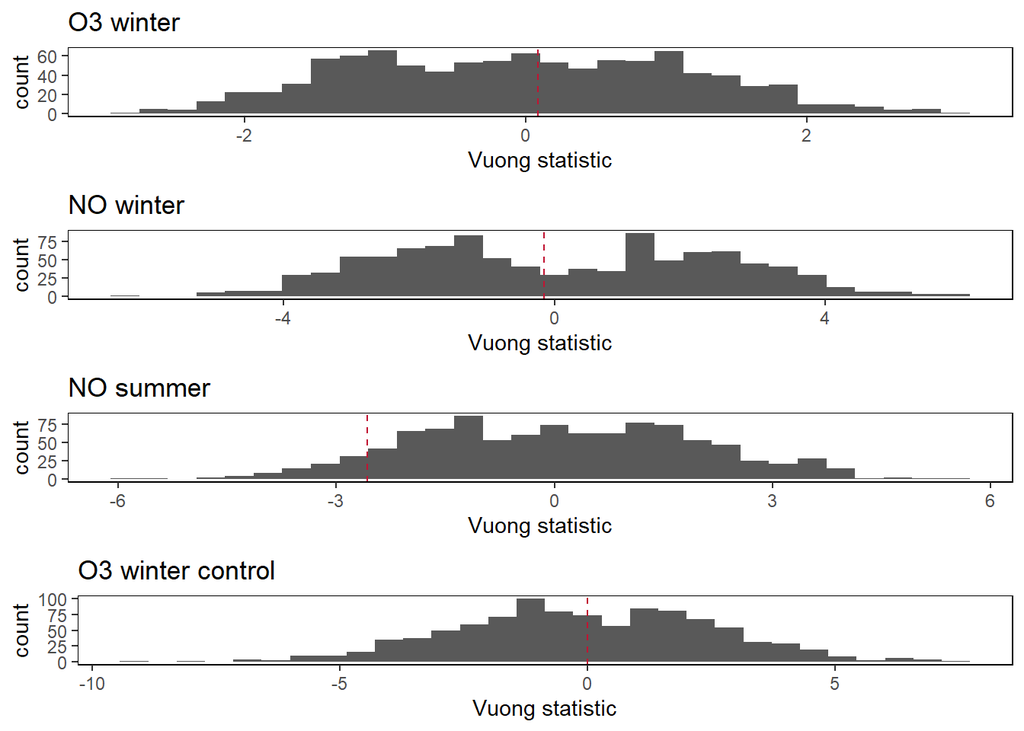

```r
grid.arrange(p1+ggtitle("O3 winter"),p2+ggtitle("NO winter"),p3+ggtitle("NO summer"),p4+ggtitle("O3 winter control"),ncol=1 )
```